# Measures of Dispersion

Measures of dispersion se hum data ki spread ya variability samajhte hain.

- Iska matlab hai ke data kitna spread out hai apne mean ke around.
- Yeh data ke variability ko measure karte hain.

1 Range:

- Range batata hai ke data kitna spread hai:

[figure not shown]

```python
data = [4,7,2,12]
data
```

```
[4, 7, 2, 12]
```

```python
Range = max(data) - min(data)
Range
```

```
10
```

Range For Group Data:

[figure not shown]

```python
import pandas as pd
class_ = ["0-10","10-20","20-30"]
f = [5,3,2]
df = pd.DataFrame({"class":class_,"f":f})
df
```

|  | class | f |
| --- | --- | --- |
| 0 | 0-10 | 5 |
| 1 | 10-20 | 3 |
| 2 | 20-30 | 2 |

```python
min_value = min([int(i) for i in class_[0].split('-')])
max_value = max([int(i) for i in class_[-1].split('-')])
Range = max_value - min_value
Range
```

```
30
```

## -> Range Examples

- Ye batata hai ke data kitna faila hua (spread out) hai.

```python
scores = [45, 50, 55, 60, 65, 70, 75]
scores
```

```
[45, 50, 55, 60, 65, 70, 75]
```

```python
max(scores) - min(scores)
```

```
30
```

- Min = 45
- Max = 75
- Range = 75 − 45 = 30
- Yani test scores 30 marks ke andar hi ghoom rahe hain → spread kam hai, data stable hai

```python
scores = [10, 20, 30, 40, 90]
scores
```

```
[10, 20, 30, 40, 90]
```

```python
max(scores) - min(scores)
```

```
80
```

- Min = 10
- Max = 90
- Range = 90 − 10 = 80
- Yani kuch students bohot kam marks le rahe, kuch bohot zyada → data uneven hai, variability zyada hai

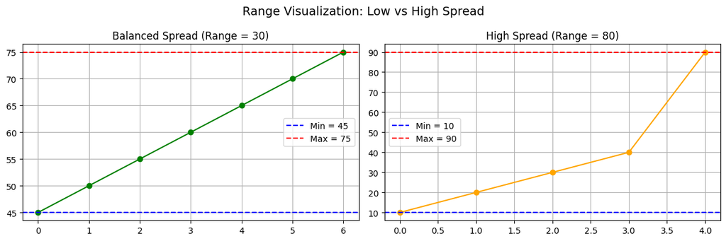

```python
import matplotlib.pyplot as plt

scores_balanced = [45, 50, 55, 60, 65, 70, 75]
scores_spread = [10, 20, 30, 40, 90]

# Range calculate
range_bal = max(scores_balanced) - min(scores_balanced)
range_spread = max(scores_spread) - min(scores_spread)

# Plot
fig, axs = plt.subplots(1, 2, figsize=(12, 4))

axs[0].plot(scores_balanced, 'o-', color='green')
axs[0].axhline(min(scores_balanced), color='blue', linestyle='--', label=f"Min = {min(scores_balanced)}")
axs[0].axhline(max(scores_balanced), color='red', linestyle='--', label=f"Max = {max(scores_balanced)}")
axs[0].set_title(f"Balanced Spread (Range = {range_bal})")
axs[0].legend()
axs[0].grid()

axs[1].plot(scores_spread, 'o-', color='orange')
axs[1].axhline(min(scores_spread), color='blue', linestyle='--', label=f"Min = {min(scores_spread)}")
axs[1].axhline(max(scores_spread), color='red', linestyle='--', label=f"Max = {max(scores_spread)}")
axs[1].set_title(f"High Spread (Range = {range_spread})")
axs[1].legend()
axs[1].grid()

plt.suptitle("Range Visualization: Low vs High Spread", fontsize=14)
plt.tight_layout()
plt.show()
```

| Use-case | Explanation |
| --- | --- |
| 🎓 **Student performance** | Range kam ho → sab ka level same hai |
| 📈 **Stock price variation** | Range zyada → stock volatile hai |
| ⚙️ **Sensor reading stability** | Range kam → system stable hai |
| 🤖 **ML data normalization** | Range help karta hai min-max scaling mein |
| ⚠️ **Outlier detect karna** | Range zyada ho to possible outlier hai |

Use Case

| Scenario | How Range Helps |
| --- | --- |
| **Feature Scaling (MinMaxScaler)** | Range use hota hai: $(x - min)/(max - min)$ |
| **Feature Selection** | Low-range features might be dropped |
| **Outlier Alert** | Jab Range bohot zyada ho, outliers detect hote hain |

- 2 Mean / Median Deviation
  - Mean / Median Deviation ek technique hai jo yeh batata hai ke:
  - "Har data point apne mean ya median se kitna door hai on average (absolute distance)."

[figure not shown]

```python
import numpy as np

data = [2, 4, 6, 8, 100]
data
```

```
[2, 4, 6, 8, 100]
```

```python
n = len(data)
n
```

```
5
```

```python
mean = np.mean(data)
median = np.median(data)

print(mean)
print(median)
```

```
24.0
6.0
```

```python
md_mean = np.sum(np.abs(np.array(data) - mean)) / n
md_median = np.sum(np.abs(np.array(data) - median)) / n

print(md_mean)
print(md_median)
```

```
30.4
20.4
```